# Regression Models Project

Ruel Laranjo | Aspiring Data Scientist

2026-03-30

# Executive Summary

This project analyzes whether transmission type (manual vs automatic) has a significant impact on fuel efficiency (miles per gallon, MPG). Using the mtcars dataset, linear regression models are applied to quantify the relationship between transmission type and MPG.

The initial results suggest that manual transmission vehicles tend to have higher fuel efficiency compared to automatic vehicles. However, when additional variables such as vehicle weight and horsepower are included, the effect of transmission type becomes less pronounced.

This analysis highlights that vehicle characteristics, particularly weight, play a more important role in determining fuel efficiency. Overall, the project demonstrates how regression modeling can be used to identify key variables influencing performance and support data-driven decision-making.

# Data Exploration

```r
data(mtcars)
head(mtcars)
```

```
##                    mpg cyl disp  hp drat    wt  qsec vs am gear carb
## Mazda RX4         21.0   6  160 110 3.90 2.620 16.46  0  1    4    4
## Mazda RX4 Wag     21.0   6  160 110 3.90 2.875 17.02  0  1    4    4
## Datsun 710        22.8   4  108  93 3.85 2.320 18.61  1  1    4    1
## Hornet 4 Drive    21.4   6  258 110 3.08 3.215 19.44  1  0    3    1
## Hornet Sportabout 18.7   8  360 175 3.15 3.440 17.02  0  0    3    2
## Valiant           18.1   6  225 105 2.76 3.460 20.22  1  0    3    1
```

The dataset contains information about fuel efficiency (MPG), engine characteristics, and transmission type. Key variables include: mpg: Miles per gallon (fuel efficiency) am: Transmission type (0 = automatic, 1 = manual) wt: Weight of the car hp: Horsepower

# Regression Analysis

```r
model1 <- lm(mpg ~ am, data = mtcars)
summary(model1)
```

```
##
## Call:
## lm(formula = mpg ~ am, data = mtcars)
##
## Residuals:
##     Min      1Q  Median      3Q     Max
## -9.3923 -3.0923 -0.2974  3.2439  9.5077
##
## Coefficients:
##             Estimate Std. Error t value Pr(>|t|)
## (Intercept)   17.147      1.125  15.247 1.13e-15 ***
## am             7.245      1.764   4.106 0.000285 ***
## ---
## Signif. codes:  0 '***' 0.001 '**' 0.01 '*' 0.05 '.' 0.1 ' ' 1
##
## Residual standard error: 4.902 on 30 degrees of freedom
## Multiple R-squared:  0.3598, Adjusted R-squared:  0.3385
## F-statistic: 16.86 on 1 and 30 DF,  p-value: 0.000285
```

The coefficient for am represents the average difference in MPG between manual and automatic cars. A positive coefficient indicates that manual transmission cars have higher fuel efficiency compared to automatic cars.

```r
model2 <- lm(mpg ~ am + wt + hp, data = mtcars)
summary(model2)
```

```
##
## Call:
## lm(formula = mpg ~ am + wt + hp, data = mtcars)
##
## Residuals:
##     Min      1Q  Median      3Q     Max
## -3.4221 -1.7924 -0.3788  1.2249  5.5317
##
## Coefficients:
##              Estimate Std. Error t value Pr(>|t|)
## (Intercept) 34.002875   2.642659  12.867 2.82e-13 ***
## am           2.083710   1.376420   1.514 0.141268
## wt          -2.878575   0.904971  -3.181 0.003574 **
## hp          -0.037479   0.009605  -3.902 0.000546 ***
## ---
## Signif. codes:  0 '***' 0.001 '**' 0.01 '*' 0.05 '.' 0.1 ' ' 1
##
## Residual standard error: 2.538 on 28 degrees of freedom
## Multiple R-squared:  0.8399, Adjusted R-squared:  0.8227
## F-statistic: 48.96 on 3 and 28 DF,  p-value: 2.908e-11
```

Model 2 adjusts for weight (wt) and horsepower (hp). Comparing the adjusted R-squared values suggests that Model 2 explains more variability in MPG and provides a better fit than Model 1.

# 📊 Model Diagnostics

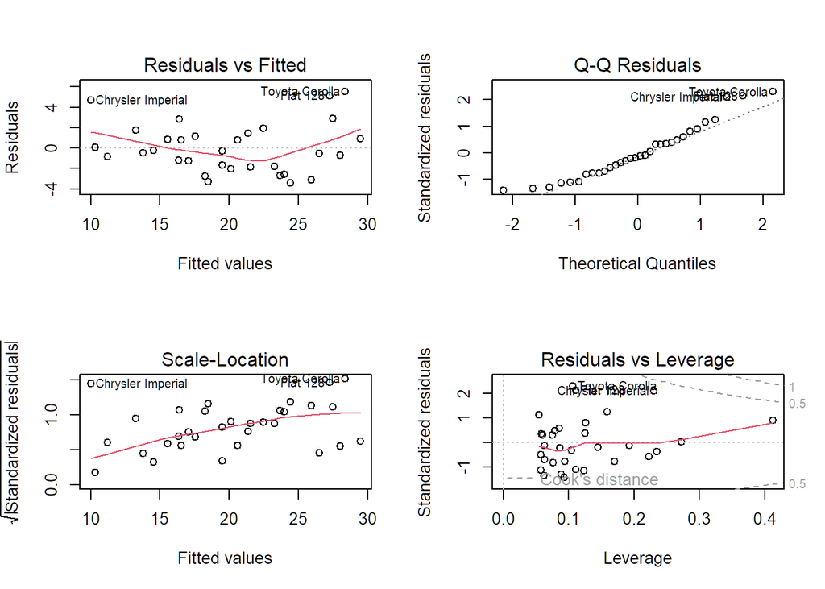

```r
par(mfrow=c(2,2))
plot(model2)
```